# Báo cáo Measurement Invariance và Clustering

Notebook này được tách thành nhiều phần nhỏ để đọc như một báo cáo phân tích. Người không hiểu code vẫn có thể theo dõi kết quả chính qua tiêu đề, bảng, biểu đồ và ghi chú diễn giải.

```python
# Thiet lap moi truong va duong dan
import os
import json
import warnings
warnings.filterwarnings('ignore')

import numpy as np
import pandas as pd
import matplotlib.pyplot as plt
import semopy
from factor_analyzer import FactorAnalyzer
import statsmodels.api as sm
import statsmodels.formula.api as smf
from IPython.display import display, HTML, Markdown

def VN(s):
    try:
        return s.encode('ascii').decode('unicode_escape')
    except UnicodeEncodeError:
        return s

BASE = os.path.abspath(os.path.join(os.getcwd(), '..'))
DATA_FILE = os.path.join(BASE, 'Cleaned_Data', '281_PKS_ThongKe_Full_v1.3.xlsx')
OUT = os.path.join(BASE, 'Phan_Tich_Chuyen_Sau', 'ket_qua_MI_Cluster')
os.makedirs(OUT, exist_ok=True)
R = {}

pd.set_option('display.max_columns', 80)
pd.set_option('display.width', 160)

STYLE = """
<style>
body { font-family: Arial, sans-serif; }
.rendered_html table { font-size: 13px; border-collapse: collapse; }
.rendered_html th { background: #f3f6fa; color: #1f2937; font-weight: 700; }
.rendered_html td, .rendered_html th { border: 1px solid #d9dee7; padding: 6px 8px; }
.note { background: #f7fbff; border-left: 4px solid #2563eb; padding: 10px 12px; margin: 10px 0 18px 0; color: #1f2937; }
</style>
"""
display(HTML(STYLE))

def show_table(df, caption=None, max_rows=30):
    if caption:
        display(Markdown('**' + caption + '**'))
    display(df.head(max_rows).style.set_properties(**{'text-align': 'left'}).set_table_styles([
        {'selector': 'th', 'props': [('text-align', 'left')]}
    ]))
    if len(df) > max_rows:
        display(Markdown(VN('_Ch\u1ec9 hi\u1ec3n th\u1ecb {}/{} d\u00f2ng. File CSV \u0111\u1ea7y \u0111\u1ee7 \u0111\u01b0\u1ee3c l\u01b0u trong th\u01b0 m\u1ee5c k\u1ebft qu\u1ea3._').format(max_rows, len(df))))

def note(text):
    display(HTML("<div class='note'><b>" + VN('Ghi ch\u00fa di\u1ec5n gi\u1ea3i:') + "</b><br>" + text + "</div>"))

print('Data file:', DATA_FILE)
print('Output folder:', OUT)
print('Data file exists:', os.path.exists(DATA_FILE))
```

```
Data file: D:\Support\HD_NCS\MsKimSon\DinhLuong\Cleaned_Data\281_PKS_ThongKe_Full_v1.3.xlsx
Output folder: D:\Support\HD_NCS\MsKimSon\DinhLuong\Phan_Tich_Chuyen_Sau\ket_qua_MI_Cluster
Data file exists: True
```

## 1. Đọc dữ liệu và tạo biến tổng hợp

Phần này đọc sheet `Statistic`, chuẩn hóa một số tên biến, tạo biến nhóm và tính điểm trung bình cho từng thang đo.

```python
df = pd.read_excel(DATA_FILE, sheet_name='Statistic')
df = df.rename(columns={'COM 4': 'COM4'})
df['COM4r'] = 7 - df['COM4']
df['RES4r'] = 7 - df['RES4']
df['Foreign'] = df['Nhom_CB'].isin([2, 4]).astype(int)
df['Leader'] = df['Nhom_CB'].isin([3, 4]).astype(int)

CONS = {
    'NOR': ['NOR1','NOR2','NOR3'], 'STR': ['STR1','STR2','STR3'], 'OPE': ['OPE1','OPE2','OPE3'],
    'LED': [f'LED{i}' for i in range(1,13)], 'COL': [f'COL{i}' for i in range(1,7)],
    'PAR': [f'PAR{i}' for i in range(1,5)], 'TRU': [f'TRU{i}' for i in range(1,5)],
    'SHA': ['SHA1','SHA2'], 'COM': ['COM1','COM2','COM3'], 'RES': ['RES1','RES2'],
    'ENG': [f'ENG{i}' for i in range(1,5)], 'GLO': [f'GLO{i}' for i in range(1,9)],
    'OCM': [f'OCM{i}' for i in range(1,4)], 'SAT_O': [f'SAT_O{i}' for i in range(1,7)],
    'SAT_J': [f'SAT_J{i}' for i in range(1,5)], 'WEG': [f'WEG{i}' for i in range(1,10)],
    'PRO': [f'PRO{i}' for i in range(1,7)],
}
for c, items in CONS.items():
    df[c] = df[items].mean(axis=1)

sample_summary = pd.DataFrame({
    VN('Ch\u1ec9 s\u1ed1'): [VN('S\u1ed1 quan s\u00e1t'), VN('S\u1ed1 tr\u01b0\u1eddng'), VN('Ng\u01b0\u1eddi Vi\u1ec7t'), VN('Ng\u01b0\u1eddi n\u01b0\u1edbc ngo\u00e0i'), VN('Gi\u00e1o vi\u00ean'), VN('Qu\u1ea3n l\u00fd')],
    VN('Gi\u00e1 tr\u1ecb'): [len(df), df['Truong'].nunique(), int((df.Foreign == 0).sum()), int((df.Foreign == 1).sum()), int((df.Leader == 0).sum()), int((df.Leader == 1).sum())]
})
construct_summary = pd.DataFrame({VN('Thang \u0111o'): list(CONS.keys()), VN('S\u1ed1 bi\u1ebfn quan s\u00e1t'): [len(v) for v in CONS.values()]})
R['group_n'] = {'Vietnamese': int((df.Foreign == 0).sum()), 'Expatriate': int((df.Foreign == 1).sum())}
show_table(sample_summary, VN('T\u1ed5ng quan m\u1eabu'))
show_table(construct_summary, VN('C\u00e1c thang \u0111o \u0111\u01b0\u1ee3c s\u1eed d\u1ee5ng'))
note(VN('D\u1eef li\u1ec7u \u0111\u00e3 \u0111\u01b0\u1ee3c \u0111\u1ecdc th\u00e0nh c\u00f4ng. C\u00e1c bi\u1ebfn t\u1ed5ng h\u1ee3p l\u00e0 \u0111i\u1ec3m trung b\u00ecnh c\u1ee7a c\u00e1c bi\u1ebfn quan s\u00e1t trong c\u00f9ng m\u1ed9t thang \u0111o.'))
```

**Tổng quan mẫu**

|  | Chỉ số | Giá trị |
| --- | --- | --- |
| 0 | Số quan sát | 281 |
| 1 | Số trường | 5 |
| 2 | Người Việt | 245 |
| 3 | Người nước ngoài | 36 |
| 4 | Giáo viên | 236 |
| 5 | Quản lý | 45 |

**Các thang đo được sử dụng**

|  | Thang đo | Số biến quan sát |
| --- | --- | --- |
| 0 | NOR | 3 |
| 1 | STR | 3 |
| 2 | OPE | 3 |
| 3 | LED | 12 |
| 4 | COL | 6 |
| 5 | PAR | 4 |
| 6 | TRU | 4 |
| 7 | SHA | 2 |
| 8 | COM | 3 |
| 9 | RES | 2 |
| 10 | ENG | 4 |
| 11 | GLO | 8 |
| 12 | OCM | 3 |
| 13 | SAT_O | 6 |
| 14 | SAT_J | 4 |
| 15 | WEG | 9 |
| 16 | PRO | 6 |

**Ghi chú diễn giải:**  
Dữ liệu đã được đọc thành công. Các biến tổng hợp là điểm trung bình của các biến quan sát trong cùng một thang đo.

## 2. Measurement Invariance: kiểm tra cấu hình thang đo

Mục tiêu là xem cùng một thang đo có vận hành tương đối giống nhau giữa nhóm người Việt và người nước ngoài hay không.

```python
MI_CONS = ['GLO', 'OCM', 'SAT_O', 'SAT_J', 'WEG', 'PRO', 'LED', 'COL']
conf_rows = []
for c in MI_CONS:
    items = CONS[c]
    if len(items) < 3:
        continue
    spec = f'{c} =~ ' + ' + '.join(items)
    row = {'Construct': c, 'Items': len(items)}
    ok = True
    for gname, gdf in [('VN', df[df.Foreign == 0]), ('EXP', df[df.Foreign == 1])]:
        try:
            m = semopy.Model(spec); m.fit(gdf[items]); s = semopy.calc_stats(m)
            row[f'CFI_{gname}'] = round(float(s['CFI'].iloc[0]), 3)
            row[f'RMSEA_{gname}'] = round(float(s['RMSEA'].iloc[0]), 3)
        except Exception:
            ok = False
            row[f'CFI_{gname}'] = np.nan; row[f'RMSEA_{gname}'] = np.nan
    row['Configural'] = 'Supported' if (ok and row.get('CFI_VN', 0) >= .85 and row.get('CFI_EXP', 0) >= .85) else 'Weak/undetermined'
    conf_rows.append(row)
conf_df = pd.DataFrame(conf_rows)
conf_df.to_csv(os.path.join(OUT, 'MI_01_configural.csv'), index=False, encoding='utf-8-sig')
R['configural'] = conf_df.to_dict('records')
show_table(conf_df, 'MI_01 - Configural invariance')
supported = int((conf_df['Configural'] == 'Supported').sum())
weak = int((conf_df['Configural'] != 'Supported').sum())
note(VN('C\u00f3 <b>{}</b> thang \u0111o \u0111\u1ea1t m\u1ee9c Supported v\u00e0 <b>{}</b> thang \u0111o c\u1ea7n th\u1eadn tr\u1ecdng. C\u00e1c thang \u0111o Weak/undetermined kh\u00f4ng nh\u1ea5t thi\u1ebft sai, nh\u01b0ng k\u1ebft qu\u1ea3 so s\u00e1nh gi\u1eefa nh\u00f3m n\u00ean \u0111\u01b0\u1ee3c di\u1ec5n gi\u1ea3i d\u00e8 d\u1eb7t h\u01a1n.').format(supported, weak))
```

**MI_01 - Configural invariance**

|  | Construct | Items | CFI_VN | RMSEA_VN | CFI_EXP | RMSEA_EXP | Configural |
| --- | --- | --- | --- | --- | --- | --- | --- |
| 0 | GLO | 8 | 0.923000 | 0.131000 | 0.886000 | 0.230000 | Supported |
| 1 | OCM | 3 | 1.000000 | inf | 1.000000 | inf | Supported |
| 2 | SAT_O | 6 | 0.955000 | 0.110000 | 1.038000 | 0.000000 | Supported |
| 3 | SAT_J | 4 | 0.975000 | 0.137000 | 1.005000 | 0.000000 | Supported |
| 4 | WEG | 9 | 0.881000 | 0.147000 | 0.691000 | 0.255000 | Weak/undetermined |
| 5 | PRO | 6 | 0.945000 | 0.128000 | 1.049000 | 0.000000 | Supported |
| 6 | LED | 12 | 0.863000 | 0.153000 | 0.852000 | 0.238000 | Supported |
| 7 | COL | 6 | 0.879000 | 0.203000 | 0.809000 | 0.298000 | Weak/undetermined |

**Ghi chú diễn giải:**  
Có **6** thang đo đạt mức Supported và **2** thang đo cần thận trọng. Các thang đo Weak/undetermined không nhất thiết sai, nhưng kết quả so sánh giữa nhóm nên được diễn giải dè dặt hơn.

## 3. Loading congruence: mức tương đồng hệ số tải

Tucker's phi càng gần 1 càng tốt. Từ `.95` trở lên thường được xem là tương đương.

```python
def tucker_phi(a, b):
    return float(np.dot(a, b) / (np.sqrt(np.dot(a, a)) * np.sqrt(np.dot(b, b))))
cong_rows = []
for c in MI_CONS:
    items = CONS[c]
    if len(items) < 3:
        continue
    try:
        f0 = FactorAnalyzer(n_factors=1, rotation=None, method='ml'); f0.fit(df.loc[df.Foreign == 0, items])
        f1 = FactorAnalyzer(n_factors=1, rotation=None, method='ml'); f1.fit(df.loc[df.Foreign == 1, items])
        l0 = np.abs(f0.loadings_[:, 0]); l1 = np.abs(f1.loadings_[:, 0])
        phi = tucker_phi(l0, l1)
        interpretation = 'Equivalent (phi >= .95)' if phi >= .95 else ('Fair (.90-.95)' if phi >= .90 else 'Non-equivalent (< .90)')
        cong_rows.append({'Construct': c, "Tucker's phi": round(phi, 3), 'Max |delta loading|': round(float(np.max(np.abs(l0 - l1))), 3), 'Interpretation': interpretation})
    except Exception:
        cong_rows.append({'Construct': c, "Tucker's phi": np.nan, 'Max |delta loading|': np.nan, 'Interpretation': 'not estimable'})
cong_df = pd.DataFrame(cong_rows)
cong_df.to_csv(os.path.join(OUT, 'MI_02_congruence.csv'), index=False, encoding='utf-8-sig')
R['congruence'] = cong_df.to_dict('records')
show_table(cong_df, 'MI_02 - Loading congruence')
not_est = int(cong_df["Tucker's phi"].isna().sum())
note(VN('C\u00f3 <b>{}</b> thang \u0111o kh\u00f4ng \u01b0\u1edbc l\u01b0\u1ee3ng \u0111\u01b0\u1ee3c Tucker phi trong c\u1ea5u h\u00ecnh hi\u1ec7n t\u1ea1i. Khi ch\u1ec9 s\u1ed1 kh\u00f4ng \u01b0\u1edbc l\u01b0\u1ee3ng \u0111\u01b0\u1ee3c, kh\u00f4ng n\u00ean d\u00f9ng b\u1ea3ng n\u00e0y l\u00e0m b\u1eb1ng ch\u1ee9ng m\u1ea1nh.').format(not_est))
```

**MI_02 - Loading congruence**

|  | Construct | Tucker's phi | Max \|delta loading\| | Interpretation |
| --- | --- | --- | --- | --- |
| 0 | GLO | nan | nan | not estimable |
| 1 | OCM | nan | nan | not estimable |
| 2 | SAT_O | nan | nan | not estimable |
| 3 | SAT_J | nan | nan | not estimable |
| 4 | WEG | nan | nan | not estimable |
| 5 | PRO | nan | nan | not estimable |
| 6 | LED | nan | nan | not estimable |
| 7 | COL | nan | nan | not estimable |

**Ghi chú diễn giải:**  
Có **8** thang đo không ước lượng được Tucker phi trong cấu hình hiện tại. Khi chỉ số không ước lượng được, không nên dùng bảng này làm bằng chứng mạnh.

## 4. DIF screening: kiểm tra item có thiên lệch giữa nhóm hay không

`Flagged = Yes` nghĩa là item cần được rà soát nội dung hoặc diễn giải thận trọng.

```python
dif_rows = []
for c in ['GLO', 'SAT_O', 'SAT_J', 'OCM']:
    items = CONS[c]
    theta = df[items].mean(axis=1)
    theta_z = (theta - theta.mean()) / theta.std()
    for item in items:
        y = (df[item] - df[item].mean()) / df[item].std()
        X = pd.DataFrame({'theta': theta_z, 'grp': df.Foreign, 'inter': theta_z * df.Foreign})
        m = sm.OLS(y, sm.add_constant(X)).fit()
        dif_rows.append({'Construct': c, 'Item': item, 'Uniform DIF (b_grp)': round(m.params['grp'], 3), 'p_uniform': round(m.pvalues['grp'], 4), 'Non-uniform (b_int)': round(m.params['inter'], 3), 'p_nonuniform': round(m.pvalues['inter'], 4), 'Flagged': 'Yes' if (m.pvalues['grp'] < .01 or m.pvalues['inter'] < .01) else 'No'})
dif_df = pd.DataFrame(dif_rows)
dif_df.to_csv(os.path.join(OUT, 'MI_03_DIF_screening.csv'), index=False, encoding='utf-8-sig')
R['dif'] = dif_df.to_dict('records')
R['dif_flagged'] = int((dif_df['Flagged'] == 'Yes').sum())
R['dif_total'] = int(len(dif_df))
flagged_dif = dif_df[dif_df.Flagged == 'Yes'].copy()
show_table(flagged_dif if len(flagged_dif) else dif_df, 'MI_03 - DIF screening')
note(VN('C\u00f3 <b>{}</b> tr\u00ean <b>{}</b> item \u0111\u01b0\u1ee3c \u0111\u00e1nh d\u1ea5u DIF. \u0110\u00e2y l\u00e0 danh s\u00e1ch \u01b0u ti\u00ean \u0111\u1ec3 xem l\u1ea1i c\u00e2u h\u1ecfi/item; ch\u01b0a n\u00ean hi\u1ec3u ngay l\u00e0 item sai.').format(R['dif_flagged'], R['dif_total']))
```

**MI_03 - DIF screening**

|  | Construct | Item | Uniform DIF (b_grp) | p_uniform | Non-uniform (b_int) | p_nonuniform | Flagged |
| --- | --- | --- | --- | --- | --- | --- | --- |
| 12 | SAT_O | SAT_O5 | 0.611000 | 0.004100 | -0.247000 | 0.053900 | Yes |
| 14 | SAT_J | SAT_J1 | -0.018000 | 0.905200 | -0.356000 | 0.000200 | Yes |
| 16 | SAT_J | SAT_J3 | 0.014000 | 0.908300 | 0.280000 | 0.000600 | Yes |
| 20 | OCM | OCM3 | -0.400000 | 0.000100 | 0.006000 | 0.925300 | Yes |

**Ghi chú diễn giải:**  
Có **4** trên **21** item được đánh dấu DIF. Đây là danh sách ưu tiên để xem lại câu hỏi/item; chưa nên hiểu ngay là item sai.

## 5. Role congruence: giáo viên so với quản lý

Phần này kiểm tra nhanh tính tương đồng tải nhân tố giữa nhóm giáo viên và nhóm quản lý.

```python
role_rows = []
for c in ['GLO', 'LED', 'COL']:
    items = CONS[c]
    if len(items) < 3:
        continue
    try:
        f0 = FactorAnalyzer(n_factors=1, rotation=None, method='ml'); f0.fit(df.loc[df.Leader == 0, items])
        f1 = FactorAnalyzer(n_factors=1, rotation=None, method='ml'); f1.fit(df.loc[df.Leader == 1, items])
        phi = tucker_phi(np.abs(f0.loadings_[:, 0]), np.abs(f1.loadings_[:, 0]))
        role_rows.append({'Construct': c, "Tucker's phi (teacher vs leader)": round(phi, 3), 'Interpretation': 'Equivalent' if phi >= .95 else 'Fair/Non-equivalent'})
    except Exception:
        role_rows.append({'Construct': c, "Tucker's phi (teacher vs leader)": np.nan, 'Interpretation': 'not estimable'})
role_df = pd.DataFrame(role_rows)
role_df.to_csv(os.path.join(OUT, 'MI_04_role_congruence.csv'), index=False, encoding='utf-8-sig')
R['role_congruence'] = role_df.to_dict('records')
show_table(role_df, 'MI_04 - Role congruence')
note(VN('B\u1ea3ng n\u00e0y gi\u00fap xem li\u1ec7u c\u1ea5u tr\u00fac thang \u0111o c\u00f3 \u1ed5n khi t\u00e1ch gi\u00e1o vi\u00ean v\u00e0 qu\u1ea3n l\u00fd hay kh\u00f4ng.'))
```

**MI_04 - Role congruence**

|  | Construct | Tucker's phi (teacher vs leader) | Interpretation |
| --- | --- | --- | --- |
| 0 | GLO | nan | not estimable |
| 1 | LED | nan | not estimable |
| 2 | COL | nan | not estimable |

**Ghi chú diễn giải:**  
Bảng này giúp xem liệu cấu trúc thang đo có ổn khi tách giáo viên và quản lý hay không.

## 6. ICC: mức độ dữ liệu bị gom cụm theo trường

`ICC(1) >= .05` thường là dấu hiệu cần chú ý đến cấu trúc cụm theo trường.

**CL_01 - ICC**

|  | Variable | ICC(1) | ICC(2) | Design effect | Effective N | Clustering matters |
| --- | --- | --- | --- | --- | --- | --- |
| 0 | GLO | 0.081000 | 0.833000 | 5.490000 | 51 | Yes |
| 1 | OCM | -0.002000 | -0.092000 | 0.920000 | 306 | Negligible |
| 2 | SAT_O | 0.112000 | 0.876000 | 7.180000 | 39 | Yes |
| 3 | SAT_J | 0.018000 | 0.504000 | 1.980000 | 142 | Negligible |
| 4 | WEG | 0.020000 | 0.539000 | 2.120000 | 132 | Negligible |
| 5 | PRO | 0.026000 | 0.597000 | 2.420000 | 116 | Negligible |
| 6 | LED | 0.033000 | 0.655000 | 2.810000 | 100 | Negligible |
| 7 | COL | 0.072000 | 0.814000 | 4.990000 | 56 | Yes |
| 8 | PAR | 0.040000 | 0.699000 | 3.190000 | 88 | Negligible |
| 9 | TRU | 0.052000 | 0.753000 | 3.840000 | 73 | Yes |
| 10 | SHA | 0.028000 | 0.615000 | 2.520000 | 111 | Negligible |

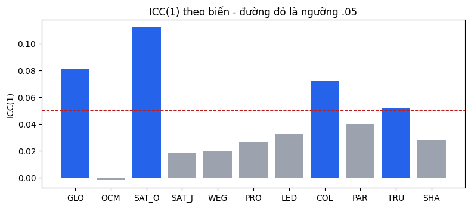

**Ghi chú diễn giải:**  
Các biến có dấu hiệu chịu ảnh hưởng theo trường: **GLO, SAT_O, COL, TRU**. Với các biến này, hồi quy cluster-robust hoặc mixed model là cách kiểm tra độ bền hợp lý.

```python
KEY = ['GLO', 'OCM', 'SAT_O', 'SAT_J', 'WEG', 'PRO', 'LED', 'COL', 'PAR', 'TRU', 'SHA']
icc_rows = []
for v in KEY:
    g = df.groupby('Truong')[v]
    k = df.groupby('Truong').size()
    k_bar = float((len(df) - (k ** 2).sum() / len(df)) / (len(k) - 1))
    msb = float(g.mean().sub(df[v].mean()).pow(2).mul(k).sum() / (len(k) - 1))
    msw = float(((df[v] - df.groupby('Truong')[v].transform('mean')) ** 2).sum() / (len(df) - len(k)))
    icc1 = (msb - msw) / (msb + (k_bar - 1) * msw) if (msb + (k_bar - 1) * msw) != 0 else np.nan
    icc2 = (msb - msw) / msb if msb != 0 else np.nan
    deff = 1 + (k_bar - 1) * icc1
    icc_rows.append({'Variable': v, 'ICC(1)': round(icc1, 3), 'ICC(2)': round(icc2, 3), 'Design effect': round(deff, 2), 'Effective N': int(round(len(df) / deff)) if deff > 0 else len(df), 'Clustering matters': 'Yes' if icc1 >= .05 else 'Negligible'})
icc_df = pd.DataFrame(icc_rows)
icc_df.to_csv(os.path.join(OUT, 'CL_01_ICC.csv'), index=False, encoding='utf-8-sig')
R['icc'] = icc_df.to_dict('records')
show_table(icc_df, 'CL_01 - ICC')
plt.figure(figsize=(8, 3.6))
colors = ['#2563eb' if x == 'Yes' else '#9ca3af' for x in icc_df['Clustering matters']]
plt.bar(icc_df['Variable'], icc_df['ICC(1)'], color=colors)
plt.axhline(.05, color='#b91c1c', linestyle='--', linewidth=1)
plt.title(VN('ICC(1) theo bi\u1ebfn - \u0111\u01b0\u1eddng \u0111\u1ecf l\u00e0 ng\u01b0\u1ee1ng .05'))
plt.ylabel('ICC(1)')
plt.tight_layout()
plt.show()
matters = ', '.join(icc_df.loc[icc_df['Clustering matters'] == 'Yes', 'Variable'])
note(VN('C\u00e1c bi\u1ebfn c\u00f3 d\u1ea5u hi\u1ec7u ch\u1ecbu \u1ea3nh h\u01b0\u1edfng theo tr\u01b0\u1eddng: <b>{}</b>. V\u1edbi c\u00e1c bi\u1ebfn n\u00e0y, h\u1ed3i quy cluster-robust ho\u1eb7c mixed model l\u00e0 c\u00e1ch ki\u1ec3m tra \u0111\u1ed9 b\u1ec1n h\u1ee3p l\u00fd.').format(matters))
```

## 7. Cluster-robust SE cho các biến kết quả

Nếu `Conclusion = Unchanged`, kết luận ý nghĩa thống kê của hệ số GLO vẫn ổn sau khi điều chỉnh cụm theo trường.

**CL_02 - OLS va cluster-robust**

|  | Outcome | beta GLO | SE naive | p naive | SE clustered | p clustered | SE ratio | Conclusion |
| --- | --- | --- | --- | --- | --- | --- | --- | --- |
| 0 | OCM | 0.662000 | 0.050500 | 0.000000 | 0.092700 | 0.000000 | 1.830000 | Unchanged |
| 1 | SAT_O | 0.762000 | 0.042700 | 0.000000 | 0.043900 | 0.000000 | 1.030000 | Unchanged |
| 2 | SAT_J | 0.656000 | 0.052800 | 0.000000 | 0.064300 | 0.000000 | 1.220000 | Unchanged |
| 3 | WEG | 0.716000 | 0.057100 | 0.000000 | 0.111600 | 0.000000 | 1.950000 | Unchanged |
| 4 | PRO | 0.738000 | 0.054600 | 0.000000 | 0.112100 | 0.000000 | 2.050000 | Unchanged |

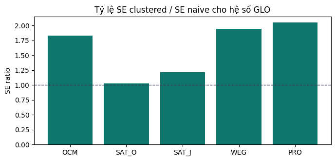

**Ghi chú diễn giải:**  
Sau khi điều chỉnh cụm theo trường, **5/5** kết luận về GLO vẫn không đổi.

```python
cmp_rows = []
for y in ['OCM', 'SAT_O', 'SAT_J', 'WEG', 'PRO']:
    d = pd.DataFrame({'y': (df[y] - df[y].mean()) / df[y].std(), 'GLO': (df['GLO'] - df['GLO'].mean()) / df['GLO'].std(), 'Foreign': df.Foreign, 'Leader': df.Leader, 'Female': df['Gioi_tinh'], 'Tenure': df['Thoi_gian_cong_tac'], 'Age': df['Do_tuoi'], 'school': df['Truong']})
    formula = 'y ~ GLO + Foreign + Leader + Female + Tenure + Age'
    m_ols = smf.ols(formula, data=d).fit()
    m_cl = smf.ols(formula, data=d).fit(cov_type='cluster', cov_kwds={'groups': d['school']})
    cmp_rows.append({'Outcome': y, 'beta GLO': round(m_ols.params['GLO'], 3), 'SE naive': round(m_ols.bse['GLO'], 4), 'p naive': round(m_ols.pvalues['GLO'], 4), 'SE clustered': round(m_cl.bse['GLO'], 4), 'p clustered': round(m_cl.pvalues['GLO'], 4), 'SE ratio': round(m_cl.bse['GLO'] / m_ols.bse['GLO'], 2), 'Conclusion': 'Unchanged' if (m_ols.pvalues['GLO'] < .05) == (m_cl.pvalues['GLO'] < .05) else 'CHANGED'})
cl_df = pd.DataFrame(cmp_rows)
cl_df.to_csv(os.path.join(OUT, 'CL_02_cluster_robust.csv'), index=False, encoding='utf-8-sig')
R['cluster_robust'] = cl_df.to_dict('records')
show_table(cl_df, 'CL_02 - OLS va cluster-robust')
plt.figure(figsize=(7, 3.4))
plt.bar(cl_df['Outcome'], cl_df['SE ratio'], color='#0f766e')
plt.axhline(1, color='#374151', linestyle='--', linewidth=1)
plt.title(VN('T\u1ef7 l\u1ec7 SE clustered / SE naive cho h\u1ec7 s\u1ed1 GLO'))
plt.ylabel('SE ratio')
plt.tight_layout()
plt.show()
unchanged = int((cl_df['Conclusion'] == 'Unchanged').sum())
note(VN('Sau khi \u0111i\u1ec1u ch\u1ec9nh c\u1ee5m theo tr\u01b0\u1eddng, <b>{}/{}</b> k\u1ebft lu\u1eadn v\u1ec1 GLO v\u1eabn kh\u00f4ng \u0111\u1ed5i.').format(unchanged, len(cl_df)))
```

## 8. Cluster-robust SE cho phương trình GLO

Kiểm tra các yếu tố dự báo GLO có còn ý nghĩa sau khi điều chỉnh cụm theo trường hay không.

```python
IVS = ['NOR','STR','OPE','LED','COL','PAR','TRU','SHA','COM','RES','ENG']
d2 = pd.DataFrame({c: (df[c] - df[c].mean()) / df[c].std() for c in IVS})
d2['y'] = (df['GLO'] - df['GLO'].mean()) / df['GLO'].std()
d2['school'] = df['Truong'].values
formula_glo = 'y ~ ' + ' + '.join(IVS)
m2o = smf.ols(formula_glo, data=d2).fit()
m2c = smf.ols(formula_glo, data=d2).fit(cov_type='cluster', cov_kwds={'groups': d2['school']})
glo_rows = []
for v in IVS:
    glo_rows.append({'Predictor': v, 'beta': round(m2o.params[v], 3), 'p naive': round(m2o.pvalues[v], 4), 'p clustered': round(m2c.pvalues[v], 4), 'SE ratio': round(m2c.bse[v] / m2o.bse[v], 2), 'Conclusion': 'Unchanged' if (m2o.pvalues[v] < .05) == (m2c.pvalues[v] < .05) else 'CHANGED'})
glo_df = pd.DataFrame(glo_rows)
glo_df.to_csv(os.path.join(OUT, 'CL_03_GLO_cluster_robust.csv'), index=False, encoding='utf-8-sig')
R['glo_cluster'] = glo_df.to_dict('records')
R['glo_changed'] = [r['Predictor'] for r in glo_rows if r['Conclusion'] == 'CHANGED']
show_table(glo_df, 'CL_03 - GLO cluster-robust')
changed = ', '.join(R['glo_changed']) if R['glo_changed'] else VN('kh\u00f4ng c\u00f3')
note(VN('C\u00e1c bi\u1ebfn thay \u0111\u1ed5i k\u1ebft lu\u1eadn sau khi \u0111i\u1ec1u ch\u1ec9nh c\u1ee5m: <b>{}</b>. \u0110\u00e2y l\u00e0 c\u00e1c h\u1ec7 s\u1ed1 c\u1ea7n di\u1ec5n gi\u1ea3i th\u1eadn tr\u1ecdng h\u01a1n.').format(changed))
```

**CL_03 - GLO cluster-robust**

|  | Predictor | beta | p naive | p clustered | SE ratio | Conclusion |
| --- | --- | --- | --- | --- | --- | --- |
| 0 | NOR | 0.116000 | 0.008000 | 0.044600 | 1.330000 | Unchanged |
| 1 | STR | 0.120000 | 0.012400 | 0.067400 | 1.380000 | CHANGED |
| 2 | OPE | 0.158000 | 0.000500 | 0.000000 | 0.500000 | Unchanged |
| 3 | LED | 0.214000 | 0.000000 | 0.000000 | 1.260000 | Unchanged |
| 4 | COL | 0.264000 | 0.000000 | 0.000000 | 0.720000 | Unchanged |
| 5 | PAR | 0.040000 | 0.157200 | 0.169500 | 1.030000 | Unchanged |
| 6 | TRU | -0.038000 | 0.374800 | 0.387400 | 1.030000 | Unchanged |
| 7 | SHA | 0.174000 | 0.000000 | 0.001500 | 1.360000 | Unchanged |
| 8 | COM | 0.033000 | 0.165200 | 0.391800 | 1.630000 | Unchanged |
| 9 | RES | 0.052000 | 0.048600 | 0.119700 | 1.270000 | CHANGED |
| 10 | ENG | -0.035000 | 0.180700 | 0.258900 | 1.190000 | Unchanged |

**Ghi chú diễn giải:**  
Các biến thay đổi kết luận sau khi điều chỉnh cụm: **STR, RES**. Đây là các hệ số cần diễn giải thận trọng hơn.

## 9. Mixed model: mô hình có random intercept theo trường

Mô hình này cho phép mỗi trường có mức nền riêng, nhằm kiểm tra thêm độ bền của kết quả.

```python
mix_rows = []
for y in ['GLO', 'OCM', 'SAT_O', 'SAT_J', 'WEG', 'PRO']:
    d3 = pd.DataFrame({'y': (df[y] - df[y].mean()) / df[y].std(), 'GLO': (df['GLO'] - df['GLO'].mean()) / df['GLO'].std(), 'Foreign': df.Foreign, 'Leader': df.Leader, 'school': df['Truong']})
    try:
        if y == 'GLO':
            md_model = smf.mixedlm('y ~ Foreign + Leader', d3, groups=d3['school']).fit()
            beta, pval, label = md_model.params['Foreign'], md_model.pvalues['Foreign'], 'Foreign'
        else:
            md_model = smf.mixedlm('y ~ GLO + Foreign + Leader', d3, groups=d3['school']).fit()
            beta, pval, label = md_model.params['GLO'], md_model.pvalues['GLO'], 'GLO'
        vc = float(md_model.cov_re.iloc[0, 0]); rv = float(md_model.scale)
        mix_rows.append({'Outcome': y, 'Key predictor': label, 'beta (mixed)': round(float(beta), 3), 'p': round(float(pval), 4), 'Var(school)': round(vc, 4), 'ICC (model)': round(vc / (vc + rv), 3)})
    except Exception:
        mix_rows.append({'Outcome': y, 'Key predictor': '-', 'beta (mixed)': np.nan, 'p': np.nan, 'Var(school)': np.nan, 'ICC (model)': np.nan})
mix_df = pd.DataFrame(mix_rows)
mix_df.to_csv(os.path.join(OUT, 'CL_04_mixed_model.csv'), index=False, encoding='utf-8-sig')
R['mixed'] = mix_df.to_dict('records')
show_table(mix_df, 'CL_04 - Mixed model')
note(VN('Mixed model l\u00e0 ki\u1ec3m tra b\u1ed5 sung cho c\u1ea5u tr\u00fac d\u1eef li\u1ec7u theo tr\u01b0\u1eddng. N\u1ebfu c\u00f3 c\u1ea3nh b\u00e1o h\u1ed9i t\u1ee5, n\u00ean xem \u0111\u00e2y l\u00e0 ph\u00e2n t\u00edch \u0111\u1ed9 b\u1ec1n ch\u1ee9 kh\u00f4ng ph\u1ea3i b\u1eb1ng ch\u1ee9ng duy nh\u1ea5t.'))
```

**CL_04 - Mixed model**

|  | Outcome | Key predictor | beta (mixed) | p | Var(school) | ICC (model) |
| --- | --- | --- | --- | --- | --- | --- |
| 0 | GLO | Foreign | -1.771000 | 0.000000 | 0.033000 | 0.051000 |
| 1 | OCM | GLO | 0.674000 | 0.000000 | 0.042500 | 0.090000 |
| 2 | SAT_O | GLO | 0.752000 | 0.000000 | 0.004000 | 0.012000 |
| 3 | SAT_J | GLO | 0.656000 | 0.000000 | 0.000000 | 0.000000 |
| 4 | WEG | GLO | 0.723000 | 0.000000 | 0.031000 | 0.052000 |
| 5 | PRO | GLO | 0.742000 | 0.000000 | 0.005800 | 0.011000 |

**Ghi chú diễn giải:**  
Mixed model là kiểm tra bổ sung cho cấu trúc dữ liệu theo trường. Nếu có cảnh báo hội tụ, nên xem đây là phân tích độ bền chứ không phải bằng chứng duy nhất.

## 10. Lưu kết quả và kết luận đọc nhanh

Phần cuối lưu file JSON tổng hợp và liệt kê các điểm chính để đưa vào báo cáo.

```python
summary_path = os.path.join(OUT, 'summary_MI_cluster.json')
with open(summary_path, 'w', encoding='utf-8') as f:
    json.dump(R, f, ensure_ascii=False, indent=1, default=str)
files = ['MI_01_configural.csv', 'MI_02_congruence.csv', 'MI_03_DIF_screening.csv', 'MI_04_role_congruence.csv', 'CL_01_ICC.csv', 'CL_02_cluster_robust.csv', 'CL_03_GLO_cluster_robust.csv', 'CL_04_mixed_model.csv', 'summary_MI_cluster.json']
saved = pd.DataFrame({VN('File \u0111\u00e3 l\u01b0u'): files, VN('\u0110\u01b0\u1eddng d\u1eabn'): [os.path.join(OUT, f) for f in files]})
show_table(saved, VN('Danh s\u00e1ch file \u0111\u1ea7u ra'), max_rows=20)
key_points = [
    VN('Configural invariance: {}/{} thang \u0111o \u0111\u1ea1t Supported.').format((conf_df['Configural'] == 'Supported').sum(), len(conf_df)),
    VN('DIF screening: {}/{} item \u0111\u01b0\u1ee3c \u0111\u00e1nh d\u1ea5u c\u1ea7n r\u00e0 so\u00e1t.').format(R['dif_flagged'], R['dif_total']),
    VN('ICC: {}/{} bi\u1ebfn c\u00f3 d\u1ea5u hi\u1ec7u clustering theo tr\u01b0\u1eddng.').format((icc_df['Clustering matters'] == 'Yes').sum(), len(icc_df)),
    VN('Outcome models: {}/{} k\u1ebft lu\u1eadn v\u1ec1 GLO kh\u00f4ng \u0111\u1ed5i sau cluster-robust SE.').format((cl_df['Conclusion'] == 'Unchanged').sum(), len(cl_df)),
    VN('GLO equation: c\u00e1c bi\u1ebfn \u0111\u1ed5i k\u1ebft lu\u1eadn sau cluster-robust l\u00e0 {}.').format(', '.join(R['glo_changed']) if R['glo_changed'] else VN('kh\u00f4ng c\u00f3')),
]
display(Markdown('### ' + VN('K\u1ebft lu\u1eadn \u0111\u1ecdc nhanh') + '\n' + '\n'.join(['- ' + x for x in key_points])))
note(VN('HTML xu\u1ea5t t\u1eeb notebook n\u00e0y c\u00f3 th\u1ec3 g\u1eedi cho ng\u01b0\u1eddi \u0111\u1ecdc kh\u00f4ng bi\u1ebft code: h\u1ecd ch\u1ec9 c\u1ea7n \u0111\u1ecdc ti\u00eau \u0111\u1ec1, b\u1ea3ng, bi\u1ec3u \u0111\u1ed3 v\u00e0 ph\u1ea7n ghi ch\u00fa di\u1ec5n gi\u1ea3i.'))
print('SAVED ->', OUT)
```

**Danh sách file đầu ra**

|  | File đã lưu | Đường dẫn |
| --- | --- | --- |
| 0 | MI_01_configural.csv | D:\Support\HD_NCS\MsKimSon\DinhLuong\Phan_Tich_Chuyen_Sau\ket_qua_MI_Cluster\MI_01_configural.csv |
| 1 | MI_02_congruence.csv | D:\Support\HD_NCS\MsKimSon\DinhLuong\Phan_Tich_Chuyen_Sau\ket_qua_MI_Cluster\MI_02_congruence.csv |
| 2 | MI_03_DIF_screening.csv | D:\Support\HD_NCS\MsKimSon\DinhLuong\Phan_Tich_Chuyen_Sau\ket_qua_MI_Cluster\MI_03_DIF_screening.csv |
| 3 | MI_04_role_congruence.csv | D:\Support\HD_NCS\MsKimSon\DinhLuong\Phan_Tich_Chuyen_Sau\ket_qua_MI_Cluster\MI_04_role_congruence.csv |
| 4 | CL_01_ICC.csv | D:\Support\HD_NCS\MsKimSon\DinhLuong\Phan_Tich_Chuyen_Sau\ket_qua_MI_Cluster\CL_01_ICC.csv |
| 5 | CL_02_cluster_robust.csv | D:\Support\HD_NCS\MsKimSon\DinhLuong\Phan_Tich_Chuyen_Sau\ket_qua_MI_Cluster\CL_02_cluster_robust.csv |
| 6 | CL_03_GLO_cluster_robust.csv | D:\Support\HD_NCS\MsKimSon\DinhLuong\Phan_Tich_Chuyen_Sau\ket_qua_MI_Cluster\CL_03_GLO_cluster_robust.csv |
| 7 | CL_04_mixed_model.csv | D:\Support\HD_NCS\MsKimSon\DinhLuong\Phan_Tich_Chuyen_Sau\ket_qua_MI_Cluster\CL_04_mixed_model.csv |
| 8 | summary_MI_cluster.json | D:\Support\HD_NCS\MsKimSon\DinhLuong\Phan_Tich_Chuyen_Sau\ket_qua_MI_Cluster\summary_MI_cluster.json |

Kết luận đọc nhanh

- Configural invariance: 6/8 thang đo đạt Supported.

- DIF screening: 4/21 item được đánh dấu cần rà soát.

- ICC: 4/11 biến có dấu hiệu clustering theo trường.

- Outcome models: 5/5 kết luận về GLO không đổi sau cluster-robust SE.

- GLO equation: các biến đổi kết luận sau cluster-robust là STR, RES.

**Ghi chú diễn giải:**  
HTML xuất từ notebook này có thể gửi cho người đọc không biết code: họ chỉ cần đọc tiêu đề, bảng, biểu đồ và phần ghi chú diễn giải.

```
SAVED -> D:\Support\HD_NCS\MsKimSon\DinhLuong\Phan_Tich_Chuyen_Sau\ket_qua_MI_Cluster
```